# DATA 606 Final Presentation Slides

2022-11-29

## Research Question

**Is there a significant difference in the mean viewership of soccer in Europe vs another continent (confederation)?**

[figure not shown]

[figure not shown]

## Data

- Viewership data for the 2010 World Cup
- Collected into a [csv file by FiveThirtyEight](https://github.com/fivethirtyeight/data/tree/master/fifa)
- 5 fields:
  - `country`
  - `confederation`
  - `tv_audience_share`
  - `population_share`
  - `gdp_weighted_share`

## Reading in Data

Read in the csv into a dataframe

```r
# load data into R dataframe
data_url <- "https://raw.githubusercontent.com/fivethirtyeight/data/master/fifa/fifa_countries_audience.csv"

fifa <- read.csv(data_url)
head(fifa)
```

[output not shown]

## Exploratory Data Analysis

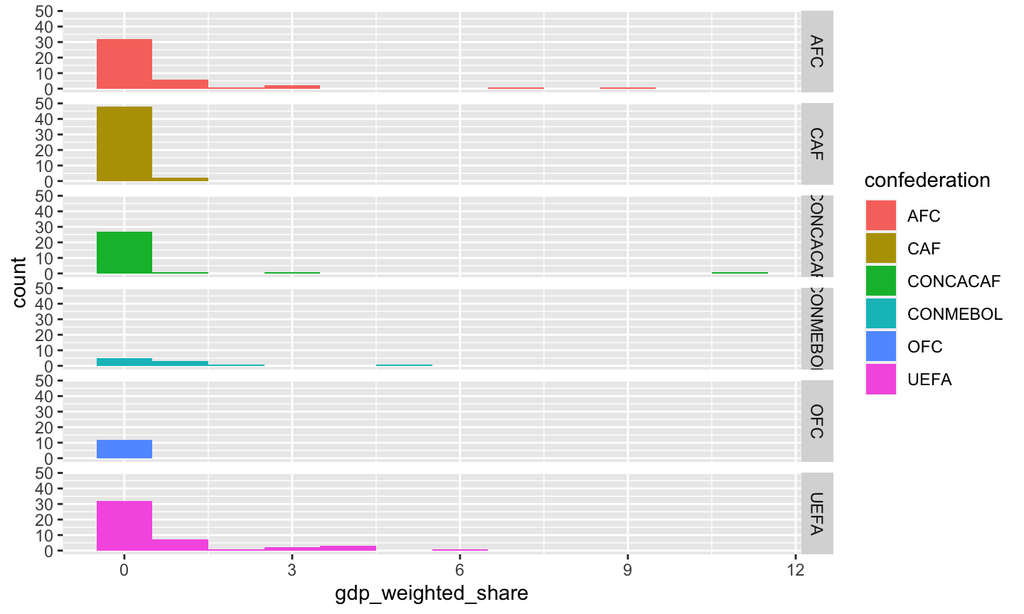

```r
# Plotting GDP Weighted share by confederation
ggplot(fifa, aes(x = gdp_weighted_share, fill = confederation)) +
  geom_histogram(binwidth=1) +
  facet_grid(confederation ~ .)
```

## TV Audience Share by Confederation

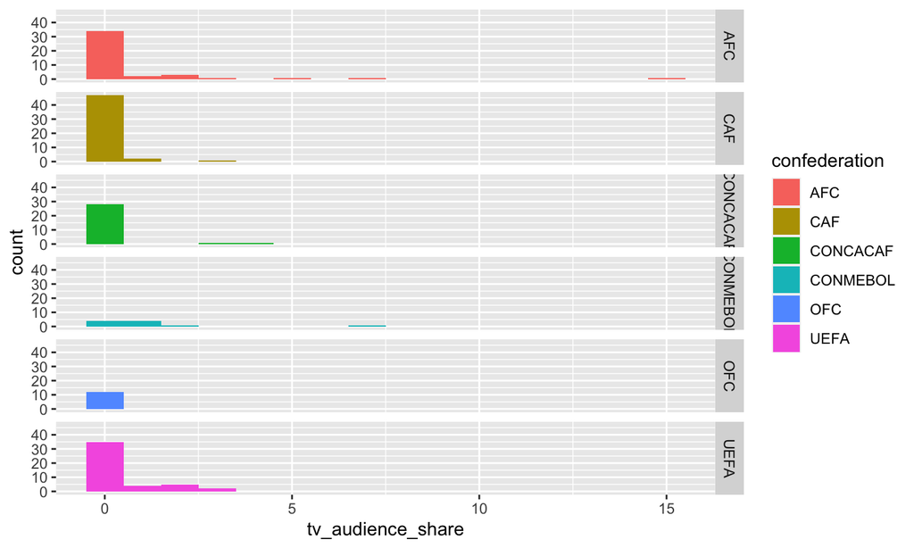

```r
ggplot(fifa, aes(x = tv_audience_share, fill = confederation)) +
  geom_histogram(binwidth=1) +
  facet_grid(confederation ~ .)
```

## Population Share by Confederation

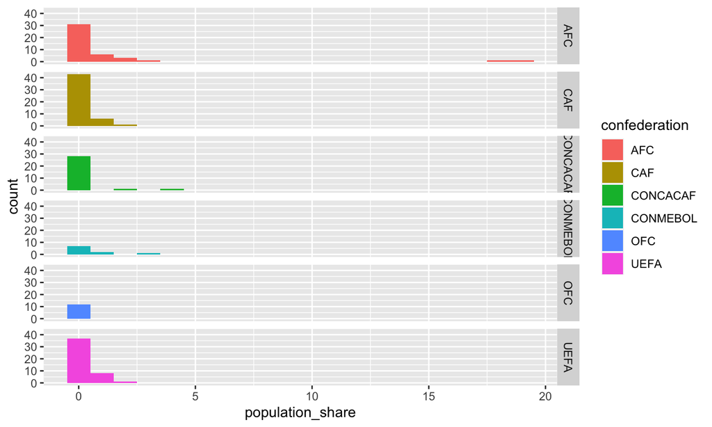

```r
ggplot(fifa, aes(x = population_share, fill = confederation)) +
  geom_histogram(binwidth=1) +
  facet_grid(confederation ~ .)
```

## What is a Confederation?

Easier to think of confederations as continents

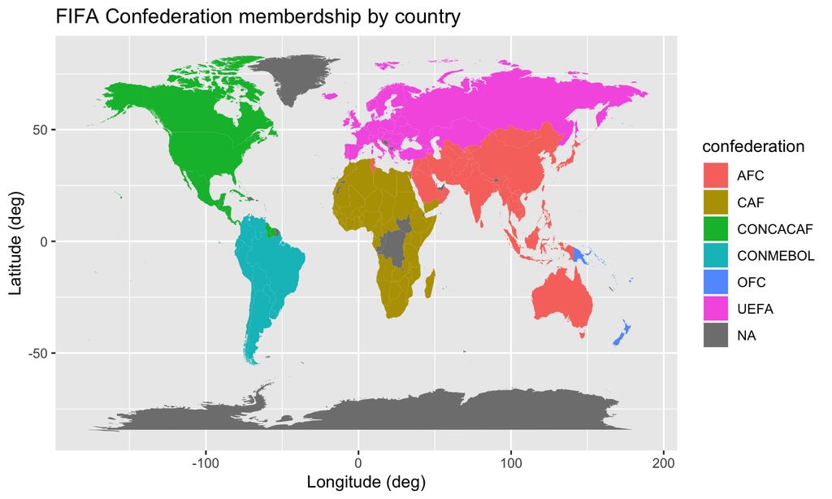

```r
ggplot(fifa_coords, aes(long, lat, group = group)) +
  geom_polygon(aes( group=group, fill=confederation)) +
  ggtitle("FIFA Confederation memberdship by country") +
  xlab("Longitude (deg)") + ylab("Latitude (deg)")
```

## TV Audience Share by Country (visualized)

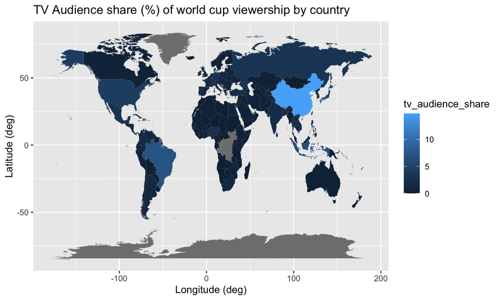

```r
# Plotting TV Audience share by country
ggplot(fifa_coords, aes(long, lat, group = group)) +
  geom_polygon(aes( group=group, fill=tv_audience_share)) +
  ggtitle("TV Audience share (%) of world cup viewership by country") +
  xlab("Longitude (deg)") + ylab("Latitude (deg)")
```

## GDP Weighted Share by Country (visualized)

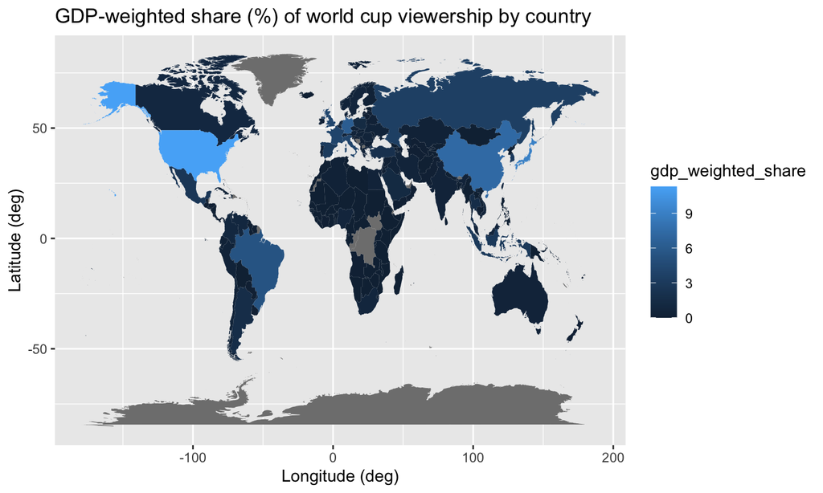

```r
ggplot(fifa_coords, aes(long, lat, group = group)) +
  geom_polygon(aes( group=group, fill=gdp_weighted_share)) +
  ggtitle("GDP-weighted share (%) of world cup viewership by country") +
  xlab("Longitude (deg)") + ylab("Latitude (deg)")
```

## Inference

T-test comparing the gdp-adjusted viewership for European vs non-European countries (\(\alpha = 0.05\))

- \(H_0\): The mean GDP-weighted viewership share of the world cup in Europe is *not higher* than that of other confederations
- \(H_a\): The mean European GDP-weighted viewership share of the world cup is *higher* than that of other confederations

## T-Test Results (GDP)

```r
europe <- fifa %>% filter(european== TRUE)
other_countries <- fifa %>% filter(european == FALSE)
# Running one-tailed t-test using R built-in
t.test(europe$gdp_weighted_share, other_countries$gdp_weighted_share,
       alternative="greater")
```

```
##
##  Welch Two Sample t-test
##
## data:  europe$gdp_weighted_share and other_countries$gdp_weighted_share
## t = 1.7859, df = 77.677, p-value = 0.03901
## alternative hypothesis: true difference in means is greater than 0
## 95 percent confidence interval:
##  0.02926207        Inf
## sample estimates:
## mean of x mean of y
## 0.8478261 0.4165517
```

Since our p-value is less than \(\alpha = 0.05\), we can reject the null hypothesis and claim that GDP-adjusted average world cup viewership in Europe is higher than that of non-European countries.

## Inference (TV Audience)

T-test on our `tv_audience_share` variable between European vs non-European countries (\(\alpha = 0.05\))

- \(H_0\): The mean tv audience viewership share of the world cup in Europe is *not higher* than that of other confederations
- \(H_a\): The mean tv audience viewership share of the world cup is *higher* than that of other confederations

## Results (TV Audience)

```r
# Running one-tailed t-test using R built-in method
t.test(europe$tv_audience_share, other_countries$tv_audience_share,
       alternative="greater")
```

```
##
##  Welch Two Sample t-test
##
## data:  europe$tv_audience_share and other_countries$tv_audience_share
## t = 0.18208, df = 151.44, p-value = 0.4279
## alternative hypothesis: true difference in means is greater than 0
## 95 percent confidence interval:
##  -0.2641503        Inf
## sample estimates:
## mean of x mean of y
## 0.5478261 0.5151724
```

## Inference (ANOVA)

Checking if there is a difference in TV Audience share between confederations

- \(H_0\): there is no significant difference between tv audience share between confederations
- \(H_a\): there is significant difference between tv audience share between confederations

## ANOVA Results (TV Audience)

```r
confederation_test <- aov(tv_audience_share ~ confederation,
                          data = fifa)
summary(confederation_test)
```

```
##                Df Sum Sq Mean Sq F value Pr(>F)
## confederation   5   26.7   5.333   2.648 0.0244 *
## Residuals     185  372.6   2.014
## ---
## Signif. codes:  0 '***' 0.001 '**' 0.01 '*' 0.05 '.' 0.1 ' ' 1
```

- Since our p-value (0.0244) is less than \(\alpha = 0.05\), we can reject the null hypothesis and assert that there **is** a statistically significant different in mean TV audience viewership between FIFA confederations.

## Inference (ANOVA GDP)

Checking if there is a difference in TV Audience share between confederations for GDP -weighted share

- \(H_0\): there is no significant difference between gdp-weighted share between confederations
- \(H_a\): there is significant difference between gdp-weighted share between confederations

## ANOVA Results (GDP)

```r
confederation_test <- aov(gdp_weighted_share ~ confederation,
                          data = fifa)
summary(confederation_test)
```

```
##                Df Sum Sq Mean Sq F value Pr(>F)
## confederation   5   23.6   4.725     2.3 0.0467 *
## Residuals     185  380.0   2.054
## ---
## Signif. codes:  0 '***' 0.001 '**' 0.01 '*' 0.05 '.' 0.1 ' ' 1
```

## Conclusion

- There may be a case that UEFA has the strongest following of soccer (or I guess we’ll have to say ‘football’)
- Multiple input factors could influence these results

## Further Work

- More recent WC viewership data
- Use league viewership data (need to adjust for home country)
- Historical analysis

## References

- (Nate Silver 2015)

Nate Silver. 2015. *How to Break FIFA*. FiveThirtyEight. https://fivethirtyeight.com/features/how-to-break-fifa/.